# `sceptre` methodology 1

Tim

2022-11-29

# Part 1: A bit of theory

Suppose we observe data $(z_1, y_1), \dots, (z_n, y_n)$, where $z_i \in \mathbb{R}^p$ and $y_i \in \mathbb{R}$. Consider the following GLM model for $y$ given $x$:
$$\begin{cases} Y_i \sim \textrm{Pois}(\mu_i) \\ \log(\mu_i) = x_i^T
\beta, \end{cases}$$
where $\beta = [\beta_1, \dots, \beta_p] \in \mathbb{R}^p$ is an unknown parameter. Suppose we obtain an estimate $\hat{\beta}$ for $\beta$ by regressing $Y = [y_1, \dots, y_n]$ onto $Z = [z_1, \dots, z_n]$. Let
$$\hat{\mu} =
\exp\left(x_i^T\hat{\beta}\right)$$
denote the $i$th fitted value of the model. Also, let
$$\mu_i = \exp\left(x_i^T \beta
\right)$$
denote the $i$th *true* conditional mean of $y_i$ given $z_i$. Finally, let $x = [x_1, \dots, x_n]$ be a vector that we seek to test for inclusion in the model. More precisely, we seek to test the conditional independence hypothesis $H_0: x_i \perp y_i | z_i.$ We consider three strategies for testing this hypothesis. We compare and contrast these strategies.

### **Strategy 1: Full score test**

Arguably the most straightforward option to test the hypothesis is to run a GLM score test. The GLM score statistic is as follows:

$$z_\textrm{score} = \frac{X^T \hat{W} \hat{M} (Y - \hat{\mu})}{\sqrt{X^T
\hat{W} X - X^T\hat{W}Z (Z^T \hat{W} Z)^{-1} Z^T\hat{W}X}}.$$

Here, $Y$ is the vector of responses, $\hat{\mu}$ is the vector of fitted means, and $Z$ is the original design matrix. Furthermore, letting $d\eta_i / d \mu_i$ denote the derivative of $\eta_i$ with respect to $\mu_i$, the matrix $M$ is defined by

$$M = \textrm{diag} \left\{d \eta_i / d\mu_i \right\}_{i=1}^n.$$

Meanwhile, $i$th weight is given by

$$W_i = \frac{1}{V(\mu_i) (d \eta_i / d \mu_i)^2},$$

and the weight matrix is

$$W = \textrm{diag} \left\{ W_i \right\}_{i=1}^n.$$

For a Poisson GLM with log link, $V(\mu_i) = \mu_i.$ Additionally, $d\eta_i/d\mu_i = 1/\mu_i.$ Thus, $W_i = \mu_i$ and $M_i = 1/\mu_i$. It follows that the numerator of the full score statistic is
$$X^T(Y - \hat{\mu}) = \sum_{i=1}^n x_i (y_i - \hat{\mu}_i).$$

Of course, when $X$ is binary, the above reduces to a sum over the raw residuals for which $x_i = 1$ i.e.

$$\sum_{x_i = 1} y_i -
\hat{\mu}_i.$$
Furthermore, the $X^T \hat{W} X$ term in the denominator is
$$X^T \hat{W} X = \sum_{i=1}^n x_i^2 \hat{\mu}_i.$$

Again, when $X$ is binary, this term reduces to a sum over the fitted means for which $x_i = 1$, i.e.
$$\sum_{x_i = 1} \hat{\mu}_i.$$
The final $X^T\hat{W}Z (Z^T \hat{W} Z)^{-1} Z^T\hat{W}X$ term is harder to simplify, but I consider how to compute this term efficiently in the next section.

### **Calculating the full score test on permuted data**

To implement the score test within the context of a permutation test, we must compute the statistic $z_\textrm{score}$ repeatedly for different $X$s. This is not totally trivial: the matrix $\hat{W}Z(Z^T \hat{W} Z)^{-1} \hat{W}$ is a dense $n \times n$ matrix and thus takes up a lot of memory and is hard to compute. The standard strategy to compute $z_\textrm{score}$ is to rewrite $z_\textrm{score}$ in terms of a weighted least squares regression and carry out this regression via a QR decomposition. This is the approach used by `statmod`. As far as I can tell, this approach does not really leverage structure in $X$ (e.g., that $X$ can be sparse and binary).

Here, I describe a simple, alternate approach to calculating $z_\textrm{score}$ that I think will be fast when $X$ is binary and sparse. First, note that the matrix $Z^T \hat{W} Z$ is a symmetric, $p \times p$ matrix. Thus, $Z^T \hat{W} Z$ can be spectrally decomposed as $U^T \Lambda U = Z^T \hat{W} Z,$ where $U$ is an orthonormal matrix and $\Lambda$ is a diagonal matrix of eigenvalues. The inverse of $Z^T \hat{W} Z$ is $(Z^T \hat{W} Z)^{-1} = U^T \Lambda^{-1} U = U^T \Lambda^{-1/2} \Lambda^{-1/2} U$. Thus,

$$X^T\hat{W}Z (Z^T \hat{W} Z)^{-1}
Z^T\hat{W}X = X^T \hat{W}Z U^T \Lambda^{-1/2} \Lambda^{-1/2} UZ^T
\hat{W} X.$$
Writing $L = \Lambda^{-1/2}UZ^T\hat{W}X \in \mathbb{R}^p,$ we see that

$$X^T \hat{W}Z U^T \Lambda^{-1/2}
\Lambda^{-1/2} UZ^T \hat{W} X = L^TL = ||L||_2^2.$$

Thus, to compute the above, it is sufficient to compute $L$, to square the terms of $L$, and then to sum these squared terms. Define the matrix $B$ by $B = \Lambda^{-1/2}UZ^T\hat{W} \in \mathbb{R}^{p \times n}.$ We need only compute $B$ once and then to share $B$ across all the $X$s. Moreover, computing $||L||^2$ is very simple when $X$ is binary. Let $I$ be the vector of indexes for which $X$ is 1. We can use the following algorithm to compute $||L||^2.$

```
outer_sum = 0
for (i in 1..p) {
  inner_sum = 0
  for (j in 1..length(I)) {
    inner_sum += B[i, I[j]]
  }
  outer_sum += inner_sum^2
}
```

This algorithm is easy to implement in C++. Meanwhile, computing the other pieces of the score statistic (i.e., $X^T \hat{W} X$ and $X^T \hat{W} \hat{M}(Y - \hat{\mu})$) is simple. A Cholesky decomposition (instead of a spectral decomposition) likely also would work. It is not clear whether the proposed procedure is as numerically stable as the QR decomposition procedure.

### **Strategy 2: Distilled score test**

Next, I consider a distilled version of the score test. Let $\hat{\mu_i}$ be the fitted value of the regression. We consider the following model for $Y$:

$$Y_i \sim \textrm{Pois}(\exp\left\{\beta x_i + \log(\hat{\mu}_i)
\right\}).$$

Assuming that $x_i$ is binary, we can express this model as

$$Y_i \sim \textrm{Pois}(\exp\left\{\beta +
\log(\hat{\mu}_i)\right\}$$

for $i$ such that $x_i=1$. For simplicity index the points such that $x_i = 1$ by $i = 1, \dots, k$. The density $f$ of $Y_i$ is
$$f(y_i; \beta) = \frac{\left[ e^{\beta +
\log(\hat{\mu}_i) } \right]^{(y_i)} e ^{ - \left[ e^{\beta +
\log(\hat{\mu_i})} \right]}}{ y_i! } = \frac{ e^{y_i\beta} e^{y_i
\log(\hat{\mu}_i)}}{ e^{\left[e^{\beta + \log(\hat{\mu}_i)} \right]}
y_i!}.$$

The likelihood is thus

The gradient of $L$ (i.e., the score) is

$$U(\beta) = \sum_{i = 1}^k y_i -
e^{\beta} \sum_{i=1}^k \hat{\mu}_i.$$

Thus, the distilled score statistic is

$$z_{\textrm{dist}} = U(0)/\sqrt{I(0)} =
\frac{\sum_{i=1}^k y_i - \hat{\mu}_i}{\sqrt{\sum_{i = 1}^k
\hat{\mu}_i}}.$$

The distilled score statistic is *not* the same as the “full” score statistic. The difference is that the $X^T\hat{W}Z (Z^T \hat{W} Z)^{-1} Z^T\hat{W}X$ term of $z_\textrm{score}$ is missing from the denominator of $z_{\textrm{dist}}$.

### **Strategy 3: Normalized sum over Pearson residuals**

A third statistic to consider is the normalized sum over the Pearson residuals. The $i$th Pearson residual $r_i$ of the Poisson model is

$$r_i = \frac{y_i - \hat{\mu}_i}{ \sqrt{\hat{\mu}_i}}.$$

The sum over the Pearson residuals $S_\textrm{Pearson}$ does not equal the distilled score statistic $z_\textrm{dist}$. The difference is that $S_\textrm{Pearson}$ normalizes the residuals and then sums them, while $z_\textrm{dist}$ sums the residuals and then normalizes them.

### **Part 1 conclusion**

The “full” score statistic, the distilled score statistic, and the sum over Pearson residuals are *not* the same. The distilled score statistic and sum over Pearson residuals require estimating the first two moments each. The full score statistic, by contrast, leverages the entire likelihood (as the test statistic is a sum over the scores normalized by the Fisher information). We likely can compute the full score statistic in a computationally efficient way via spectral decomposition and rewriting the statistic.

# Part 2: Simulations

Next, I run some simulations to compare the above statistics — $S_\textrm{Pearson}$, $z_\textrm{dist}$, and $z_\textrm{score}$ — on simulated data.

### **Simulation 1: Uncorrelated covariates**

I generate simulated from a Poisson GLM with covariates $Z$ and response $Y$. I test for association between a new, binary vector $X$ and $Y$ (conditional on $Z$) using the three strategies discussed above. Importantly, the vector $X$ is marginally independentof the covariates $Z$. I generate $B = 2000$ datasets and compute $z_\textrm{score}$, $z_\textrm{distilled}$, and $S_\textrm{Pearson}$ on each of these datasets. Finally, I create of histogram of these statistics to visualize their distributions.

The code to run the experiment is below.

```r
run_experiment <- function(fitted_means, n_rep, correlated) {
  n <- 5000
  beta_v <- c(1, 2, 1)
  dat <- matrix(data = c(rep(1, n),
                         x1 = rbinom(n, 1, 0.4),
                         x2 = rnorm(n)),
                ncol = 3)
  lin_pred <- as.numeric(dat %*% beta_v)
  mus <- exp(lin_pred)

  if (correlated) {
    x_test <- sapply(binomial()$linkinv(dat[,3] - 0.1), function(curr_mu) rbinom(n = 1, size = 1, prob = curr_mu))
  } else {
    x_test <- rbinom(n = n, size = 1, prob = 0.5)
  }

  out <- sapply(X = seq(1, n_rep), FUN = function(i) {
    y <- sapply(mus, function(curr_mu) rpois(n = 1, lambda = curr_mu))

    # we do a good job of estimating the parameters via glm
    fit <- glm(y ~ dat[,-1], family = poisson)
    mu_hat <- fit$fitted.values
    z_score_full <- statmod::glm.scoretest(fit = fit, x_test)

    # next, get the distilled z-score
    y_1 <- y[x_test == 1]
    mu_hat_1 <- if (fitted_means) mu_hat[x_test == 1] else mus[x_test == 1]
    s_y <- sum(y_1)
    s_mu_hat <- sum(mu_hat_1)

    # get the distilled z-score
    z_score_distilled <- (s_y - s_mu_hat)/sqrt(s_mu_hat)

    # get the normalized pearson residual sum
    pearson_resid <- (y_1 - mu_hat_1)/sqrt(mu_hat_1)
    sum_pearson <- sum(pearson_resid)
    norm_sum_pearson <- (1/sqrt(length(pearson_resid))) * sum_pearson

    # get the gcm
    r <- y_1 - mu_hat_1
    gcm <- 1/sqrt(length(r)) * sum(r)/sd(r)

    c(z_score_distilled = z_score_distilled,
      z_score_full = z_score_full,
      norm_sum_pearson = norm_sum_pearson,
      gcm = gcm)
  }) |> t()
}

out <- run_experiment(fitted_means = TRUE, n_rep = 2000, correlated = FALSE)
x_grid <- seq(from = -3.5, to = 3.5, by = 0.01)
y <- dnorm(x_grid)
```

Below is the distribution of $z_\textrm{score}$. We see it is N(0,1).

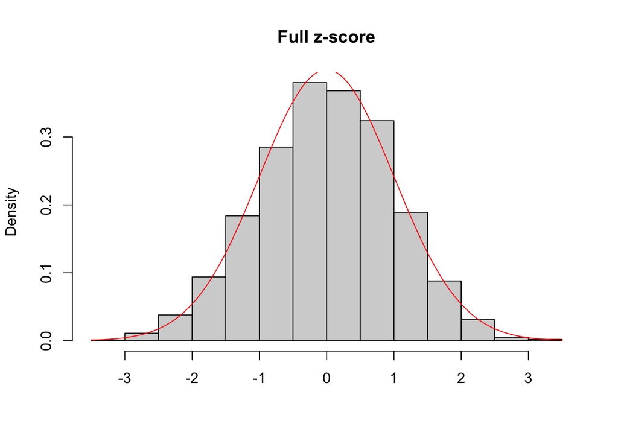

```r
x_grid <- seq(from = -3.5, to = 3.5, by = 0.01)
y <- dnorm(x_grid)

hist(out[,"z_score_full"], freq = FALSE, breaks = 20,
     main = "Full z-score", xlab = "")
lines(x = x_grid, y = y, col = "red")
```

Next, I plot $z_\textrm{dist}$. Its distribution is approximately N(0, 0.7).

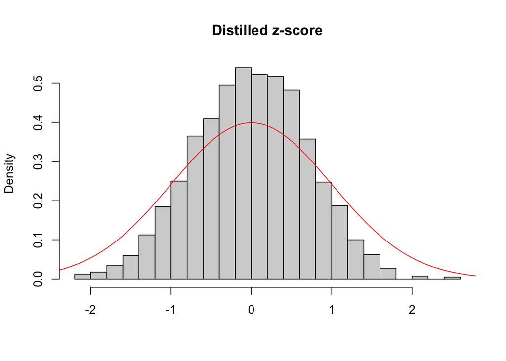

```r
hist(out[,"z_score_distilled"], freq = FALSE, breaks = 20,
     main = "Distilled z-score", xlab = "")
lines(x = x_grid, y = y, col = "red")
```

Finally, I plot $S_\textrm{Pearson}$. The distribution of this statistic again is approximately N(0, 0.7).

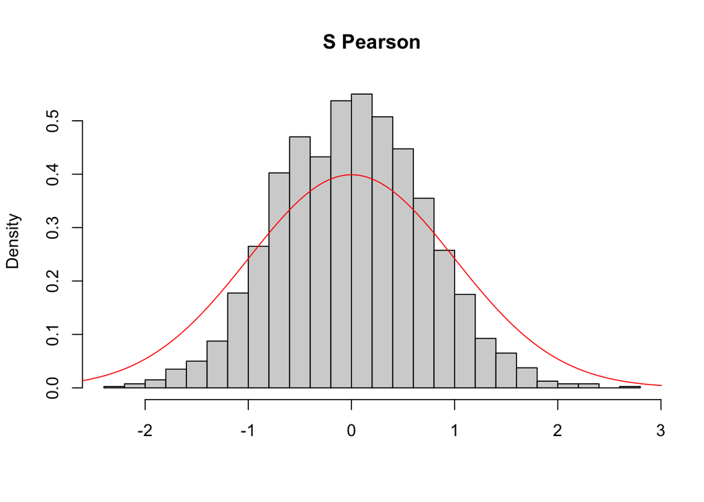

```r
hist(out[,"norm_sum_pearson"], freq = FALSE, breaks = 20,
     main = "S Pearson", xlab = "")
lines(x = x_grid, y = y, col = "red")
```

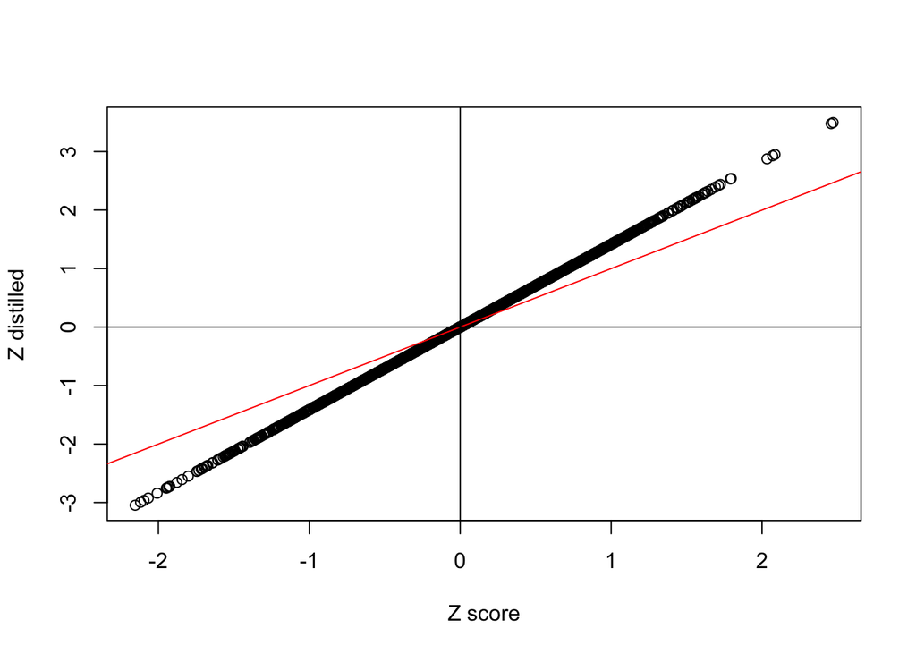

```r
plot(out[,"z_score_distilled"], out[,"z_score_full"], ylab = "Z distilled", xlab = "Z score")
abline(a = 0, b = 1, col = "red")
abline(h = 0)
abline(v = 0)
```

```r
lm(out[,"z_score_full"] ~ out[,"z_score_distilled"])
```

```
##
## Call:
## lm(formula = out[, "z_score_full"] ~ out[, "z_score_distilled"])
##
## Coefficients:
##                (Intercept)  out[, "z_score_distilled"]
##                  8.924e-07                   1.415e+00
```

Next, plotting $z_\textrm{dist}$ against $S_\textrm{Pearson}$, we see that the points form a cloud along the identity line y = x.

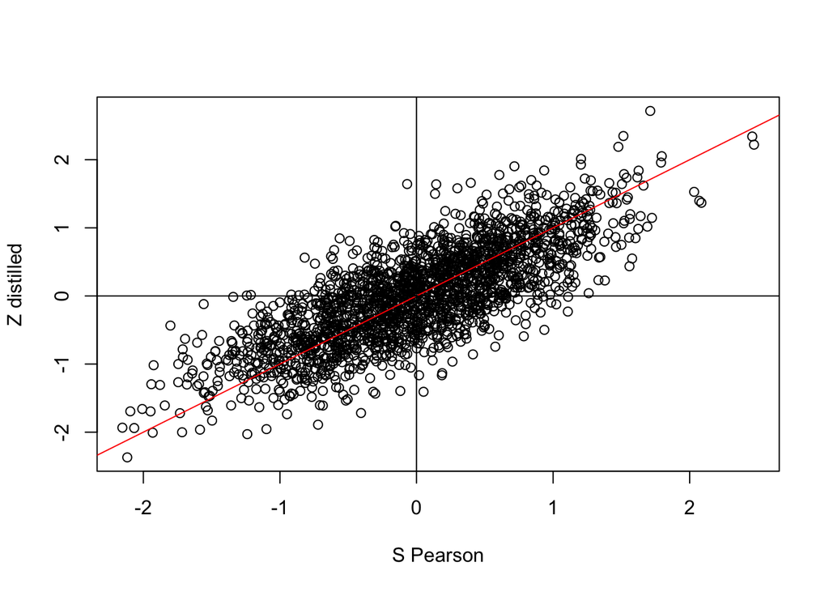

```r
plot(out[,"z_score_distilled"], out[,"norm_sum_pearson"], ylab = "Z distilled", xlab = "S Pearson")
abline(a = 0, b = 1, col = "red")
abline(h = 0)
abline(v = 0)
```

### **Simulation 2: Correlated covariates**

Next, I generate the vector $X$ in such a way that $X$ is marginally dependent on $Z$. (In other words, the problem is confounded.) I test for association between $X$ and $Y$ (conditional on $Z$) using the three methods above.

```r
out <- run_experiment(fitted_means = TRUE, n_rep = 2000, correlated = TRUE)
x_grid <- seq(from = -3.5, to = 3.5, by = 0.01)
y <- dnorm(x_grid)
```

I plot the distribution of $z_\textrm{score}$. Again, it is N(0,1).

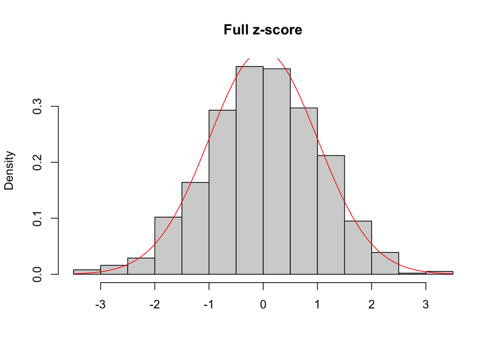

```r
hist(out[,"z_score_full"], freq = FALSE, breaks = 20,
     main = "Full z-score", xlab = "")
lines(x = x_grid, y = y, col = "red")
```

Next, I plot $z_\textrm{dist}$. Its distribution has *changed* to about N(0, 0.5).

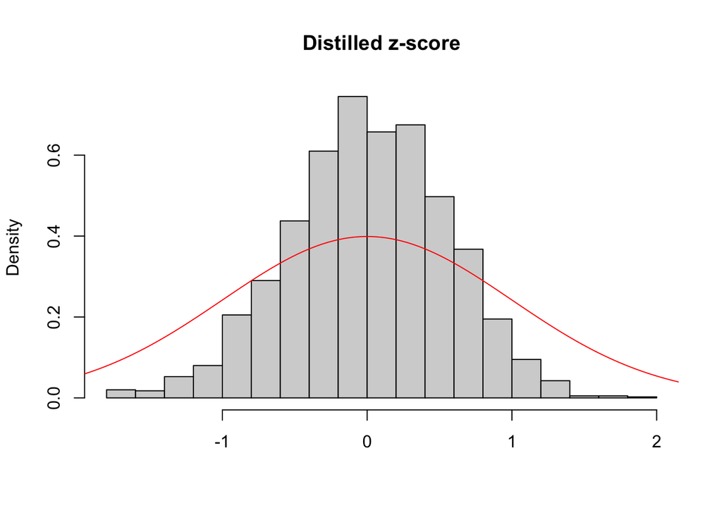

```r
hist(out[,"z_score_distilled"], freq = FALSE, breaks = 20,
     main = "Distilled z-score", xlab = "")
lines(x = x_grid, y = y, col = "red")
```

Finally, I plot $S_\textrm{Pearson}$. Again, its distribution has *changed* to approximately N(0, 0.5).

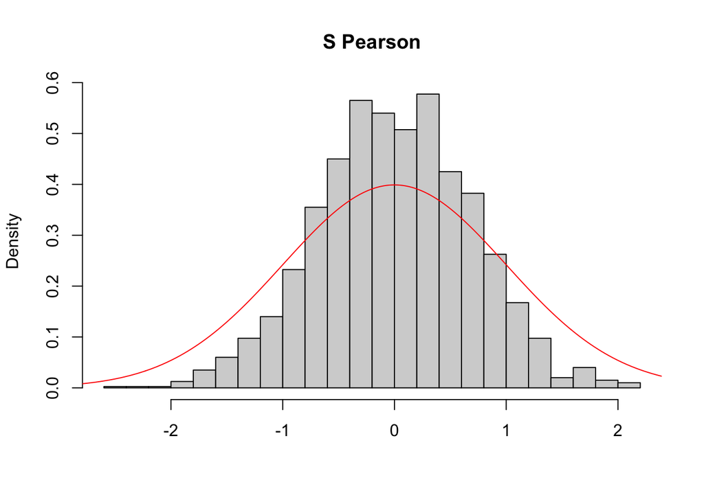

```r
hist(out[,"norm_sum_pearson"], freq = FALSE, breaks = 20,
     main = "S Pearson", xlab = "")
lines(x = x_grid, y = y, col = "red")
```

Plotting $z_\textrm{dist}$ against $z_\textrm{score}$, we see again that the former is a constant multiple of the latter. However, the proportionality constant has changed to about 2.

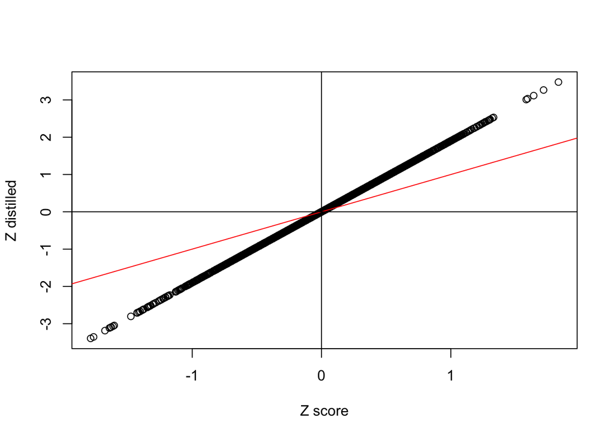

```r
plot(out[,"z_score_distilled"], out[,"z_score_full"], ylab = "Z distilled", xlab = "Z score")
abline(a = 0, b = 1, col = "red")
abline(h = 0)
abline(v = 0)
```

```r
lm(out[,"z_score_full"] ~ out[,"z_score_distilled"])
```

```
##
## Call:
## lm(formula = out[, "z_score_full"] ~ out[, "z_score_distilled"])
##
## Coefficients:
##                (Intercept)  out[, "z_score_distilled"]
##                 -1.195e-05                   1.900e+00
```

Next, plotting $z_\textrm{dist}$ against $S_\textrm{Pearson}$, we see that the points again form a cloud along the identity line y = x.

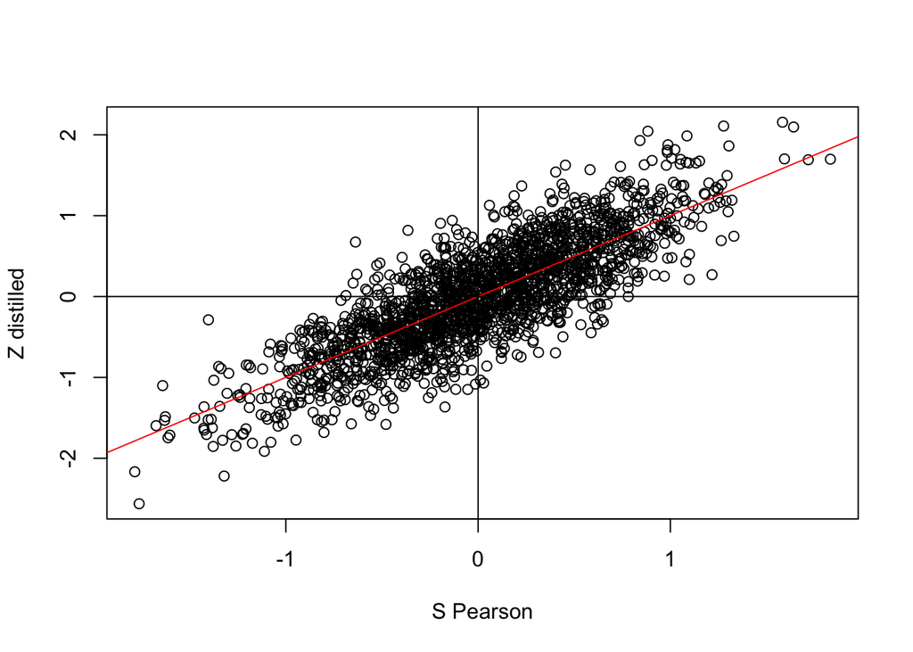

```r
plot(out[,"z_score_distilled"], out[,"norm_sum_pearson"], ylab = "Z distilled", xlab = "S Pearson")
abline(a = 0, b = 1, col = "red")
abline(h = 0)
abline(v = 0)
```

### **Why are** $z_\textrm{dist}$ and $S_\textrm{Pearson}$ not N(0,1)?

We see clearly that the statistics $z_\textrm{dist}$ and $S_\textrm{Pearson}$ are not N(0,1). The full score statistic $z_\textrm{score}$, by contrast, is. Why is this the case? These statistics have essentially the same numerator (i.e., the raw residual). The difference between these statistics is that they normalize by different factors, and $z_\textrm{dist}$ and $S_\textrm{Pearson}$ normalize by the “wrong” factor. Recall the distilled score statistic

$$z_{\textrm{dist}} = \frac{\sum_{x_i=1}
y_i - \hat{\mu}_i}{\sqrt{\sum_{x_i = 1} \hat{\mu}_i}}.$$

Next, consider the “theoretical” analogue of the distilled score statistic in which we replace $\hat{\mu}_i$ by $\mu_i$:

$$z_\textrm{dist, theory} :=
\frac{\sum_{x_i=1} y_i - \mu_i}{\sqrt{\sum_{x_i = 1}
\mu_i}}.$$

It is clear that the “theoretical” distilled score statistic is $N(0,1)$. We have that

$$\mathbb{E}(y_i - \mu_i) = 0,$$

while

$$\mathbb{V}(y_i - \mu_i) = \mathbb{V}(y_i) = \mu_i.$$

Thus,
$$\mathbb{E} \left\{\sum_{x_i = 1}
y_i - \mu_i \right\} = 0,$$

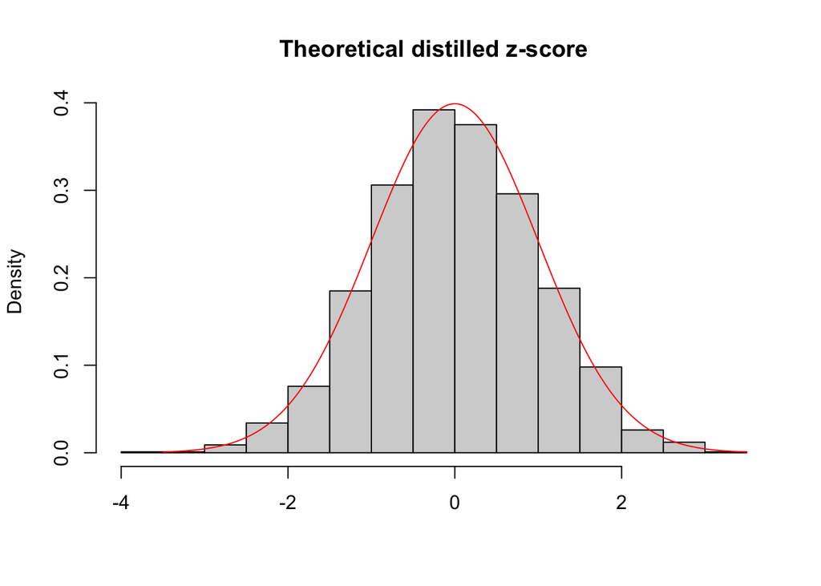

```r
out <- run_experiment(fitted_means = FALSE, n_rep = 2000, correlated = FALSE)
x_grid <- seq(from = -3.5, to = 3.5, by = 0.01)
y <- dnorm(x_grid)

hist(out[,"z_score_distilled"], freq = FALSE, breaks = 20,
     main = "Theoretical distilled z-score", xlab = "")
lines(x = x_grid, y = y, col = "red")
```

In summary the problem with the distilled score statistic is that the variance of the sum of the raw residuals $\sum_{x_i=1} y_i - \hat{\mu}_i$ is not $\sqrt{\sum_{x_i = 1} \hat{\mu}_i}$ but rather $\sqrt{\sum_{x_i = 1} \hat{\mu}_i - X^T\hat{W}Z (Z^T \hat{W} Z)^{-1} Z^T\hat{W}X}$. Similar reasoning holds for the sum of the Pearson residuals statistic.

# Conclusion and implications

Contrary to what we anticipated, the “full” score statistic, the distilled score statistic, and the sum over Pearson residuals statistic are not the same. Moreover, these statistics differ in an important way: the “full” score statistic is N(0,1) regardless of whether $X$ and $Z$ are dependent; by contrast, the distilled score statistic and sum over Pearson residuals have different distributions depending on whether $X$ and $Z$ are dependent.

A statistic is CAMP-friendly only if its distribution is invariant to the correlation structure between $X$ and $Z$. Thus, the “full” score statistic is CAMP-friendly. By contrast, the distilled score statistic and the sum over Pearson residuals are (at best) only approximately CAMP-friendly. Given that the variance of the distilled score statistic and sum over Pearson residuals decreases as $X$ and $Z$ become more correlated, I anticipate that using these statistics (instead of the “full” score statistic) leads to a loss of power. Additionally, the full score statistic (as far as I can tell) leverages all moments of the distribution, whereas the latter two statistics leverage only the first two moments of the distribution. This seems consistent with the loss in power hypothesis.